# Exploratory Analysis

```python
import matplotlib as mp
import matplotlib.pyplot as plt
import seaborn as sb
import numpy as np
import pandas as pd
from IPython.core.display import display, HTML
```

```python
display(HTML("<style>.container { width:90% !important; }</style>"))
pd.set_option('display.max_columns', None)
%matplotlib inline
```

```python
data = pd.read_csv('..\\prosperLoanData.csv')
```

```python
data.head(50)
```

[output not shown]

```python
data.describe()
```

|  | ListingNumber | Term | BorrowerAPR | BorrowerRate | LenderYield | EstimatedEffectiveYield | EstimatedLoss | EstimatedReturn | ProsperRating (numeric) | ProsperScore | ListingCategory (numeric) | EmploymentStatusDuration | CreditScoreRangeLower | CreditScoreRangeUpper | CurrentCreditLines | OpenCreditLines | TotalCreditLinespast7years | OpenRevolvingAccounts | OpenRevolvingMonthlyPayment | InquiriesLast6Months | TotalInquiries | CurrentDelinquencies | AmountDelinquent | DelinquenciesLast7Years | PublicRecordsLast10Years | PublicRecordsLast12Months | RevolvingCreditBalance | BankcardUtilization | AvailableBankcardCredit | … |
| --- | --- | --- | --- | --- | --- | --- | --- | --- | --- | --- | --- | --- | --- | --- | --- | --- | --- | --- | --- | --- | --- | --- | --- | --- | --- | --- | --- | --- | --- | --- |
| count | 1.139370e+05 | 113937.000000 | 113912.000000 | 113937.000000 | 113937.000000 | 84853.000000 | 84853.000000 | 84853.000000 | 84853.000000 | 84853.000000 | 113937.000000 | 106312.000000 | 113346.000000 | 113346.000000 | 106333.000000 | 106333.000000 | 113240.000000 | 113937.00000 | 113937.000000 | 113240.000000 | 112778.000000 | 113240.000000 | 106315.000000 | 112947.000000 | 113240.000000 | 106333.000000 | 1.063330e+05 | 106333.000000 | 106393.000000 | … |
| mean | 6.278857e+05 | 40.830248 | 0.218828 | 0.192764 | 0.182701 | 0.168661 | 0.080306 | 0.096068 | 4.072243 | 5.950067 | 2.774209 | 96.071582 | 685.567731 | 704.567731 | 10.317192 | 9.260164 | 26.754539 | 6.96979 | 398.292161 | 1.435085 | 5.584405 | 0.592052 | 984.507059 | 4.154984 | 0.312646 | 0.015094 | 1.759871e+04 | 0.561309 | 11210.225447 | … |
| std | 3.280762e+05 | 10.436212 | 0.080364 | 0.074818 | 0.074516 | 0.068467 | 0.046764 | 0.030403 | 1.673227 | 2.376501 | 3.996797 | 94.480605 | 66.458275 | 66.458275 | 5.457866 | 5.022644 | 13.637871 | 4.63097 | 447.159711 | 2.437507 | 6.429946 | 1.978707 | 7158.270157 | 10.160216 | 0.727868 | 0.154092 | 3.293640e+04 | 0.317918 | 19818.361309 | … |
| min | 4.000000e+00 | 12.000000 | 0.006530 | 0.000000 | -0.010000 | -0.182700 | 0.004900 | -0.182700 | 1.000000 | 1.000000 | 0.000000 | 0.000000 | 0.000000 | 19.000000 | 0.000000 | 0.000000 | 2.000000 | 0.00000 | 0.000000 | 0.000000 | 0.000000 | 0.000000 | 0.000000 | 0.000000 | 0.000000 | 0.000000 | 0.000000e+00 | 0.000000 | 0.000000 | … |
| 25% | 4.009190e+05 | 36.000000 | 0.156290 | 0.134000 | 0.124200 | 0.115670 | 0.042400 | 0.074080 | 3.000000 | 4.000000 | 1.000000 | 26.000000 | 660.000000 | 679.000000 | 7.000000 | 6.000000 | 17.000000 | 4.00000 | 114.000000 | 0.000000 | 2.000000 | 0.000000 | 0.000000 | 0.000000 | 0.000000 | 0.000000 | 3.121000e+03 | 0.310000 | 880.000000 | … |
| 50% | 6.005540e+05 | 36.000000 | 0.209760 | 0.184000 | 0.173000 | 0.161500 | 0.072400 | 0.091700 | 4.000000 | 6.000000 | 1.000000 | 67.000000 | 680.000000 | 699.000000 | 10.000000 | 9.000000 | 25.000000 | 6.00000 | 271.000000 | 1.000000 | 4.000000 | 0.000000 | 0.000000 | 0.000000 | 0.000000 | 0.000000 | 8.549000e+03 | 0.600000 | 4100.000000 | … |
| 75% | 8.926340e+05 | 36.000000 | 0.283810 | 0.250000 | 0.240000 | 0.224300 | 0.112000 | 0.116600 | 5.000000 | 8.000000 | 3.000000 | 137.000000 | 720.000000 | 739.000000 | 13.000000 | 12.000000 | 35.000000 | 9.00000 | 525.000000 | 2.000000 | 7.000000 | 0.000000 | 0.000000 | 3.000000 | 0.000000 | 0.000000 | 1.952100e+04 | 0.840000 | 13180.000000 | … |
| max | 1.255725e+06 | 60.000000 | 0.512290 | 0.497500 | 0.492500 | 0.319900 | 0.366000 | 0.283700 | 7.000000 | 11.000000 | 20.000000 | 755.000000 | 880.000000 | 899.000000 | 59.000000 | 54.000000 | 136.000000 | 51.00000 | 14985.000000 | 105.000000 | 379.000000 | 83.000000 | 463881.000000 | 99.000000 | 38.000000 | 20.000000 | 1.435667e+06 | 5.950000 | 646285.000000 | … |

```python
data.info()
```

```
<class 'pandas.core.frame.DataFrame'>
RangeIndex: 113937 entries, 0 to 113936
Data columns (total 81 columns):
ListingKey                             113937 non-null object
ListingNumber                          113937 non-null int64
ListingCreationDate                    113937 non-null object
CreditGrade                            28953 non-null object
Term                                   113937 non-null int64
LoanStatus                             113937 non-null object
ClosedDate                             55089 non-null object
BorrowerAPR                            113912 non-null float64
BorrowerRate                           113937 non-null float64
LenderYield                            113937 non-null float64
EstimatedEffectiveYield                84853 non-null float64
EstimatedLoss                          84853 non-null float64
EstimatedReturn                        84853 non-null float64
ProsperRating (numeric)                84853 non-null float64
ProsperRating (Alpha)                  84853 non-null object
ProsperScore                           84853 non-null float64
ListingCategory (numeric)              113937 non-null int64
BorrowerState                          108422 non-null object
Occupation                             110349 non-null object
EmploymentStatus                       111682 non-null object
EmploymentStatusDuration               106312 non-null float64
IsBorrowerHomeowner                    113937 non-null bool
CurrentlyInGroup                       113937 non-null bool
GroupKey                               13341 non-null object
DateCreditPulled                       113937 non-null object
CreditScoreRangeLower                  113346 non-null float64
CreditScoreRangeUpper                  113346 non-null float64
FirstRecordedCreditLine                113240 non-null object
CurrentCreditLines                     106333 non-null float64
OpenCreditLines                        106333 non-null float64
TotalCreditLinespast7years             113240 non-null float64
OpenRevolvingAccounts                  113937 non-null int64
OpenRevolvingMonthlyPayment            113937 non-null float64
InquiriesLast6Months                   113240 non-null float64
TotalInquiries                         112778 non-null float64
CurrentDelinquencies                   113240 non-null float64
AmountDelinquent                       106315 non-null float64
```

[output cut: 31 more lines]

```
LP_CustomerPayments                    113937 non-null float64
LP_CustomerPrincipalPayments           113937 non-null float64
LP_InterestandFees                     113937 non-null float64
LP_ServiceFees                         113937 non-null float64
LP_CollectionFees                      113937 non-null float64
LP_GrossPrincipalLoss                  113937 non-null float64
LP_NetPrincipalLoss                    113937 non-null float64
LP_NonPrincipalRecoverypayments        113937 non-null float64
PercentFunded                          113937 non-null float64
Recommendations                        113937 non-null int64
InvestmentFromFriendsCount             113937 non-null int64
InvestmentFromFriendsAmount            113937 non-null float64
Investors                              113937 non-null int64
dtypes: bool(3), float64(50), int64(11), object(17)
memory usage: 68.1+ MB
```

##### Overview

In this exploration, I aim to follow a basic path.

1. Get a basic overview of the data, identify global patterns and occurences to help identify which variables I'd like to concentrate on and what questions I'd like to answer.
2. Start with univariate exploration. What to the variables I chose sesem to be doing?
3. Bi. and multivariate exploration. What do groups of variables seem to be doing in the larger picture? Are we able to answer the questions we posed earlier?

First, I'll try getting a general overview of the data, see if there are any global patterns I can identify, and figure out which variables I'd like to zoom in on to explore further.

Lastly, I'm going to explore the dataset as if I'm an investor myself whos trying to see if Prosper is a good place to invest based on a couple of parameters that banks, investors and other institutions usually use to decide if a borrower is capable of repaying a loan.

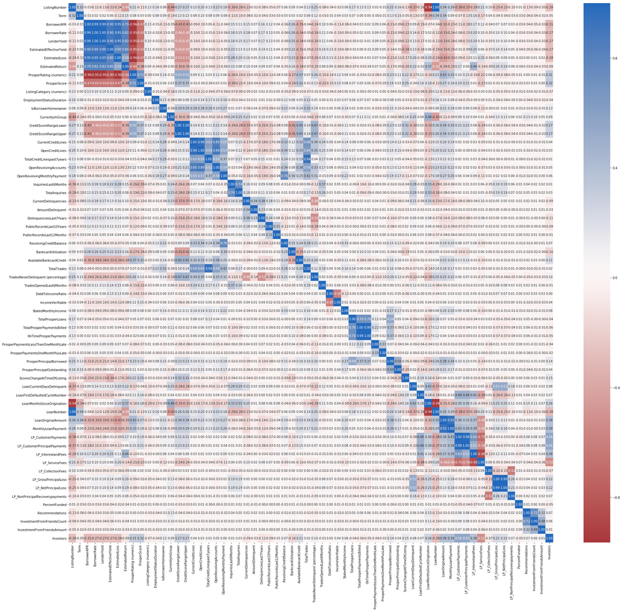

```python
#Get the heatmap of the entire dataset.
plt.figure(figsize=(35,32))
sb.heatmap(data.corr(), annot = True, cmap = 'vlag_r', fmt = '.2f');
```

#### Targeted Heatmaps

There seem to be two major blocks of correlation here. I will try getting a closer look at these variables and see what these variables mean (using the dictionary or other sources)

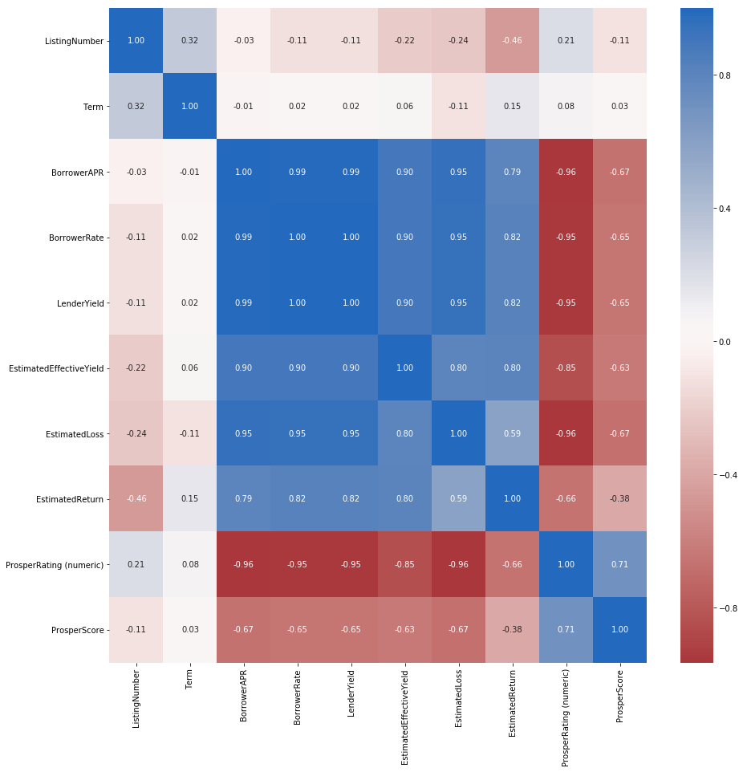

```python
#Test out some targeted heatmaps
plt.figure(figsize=(15,15))
dataspliceA = data[data.columns[1:16]]
sb.heatmap(dataspliceA.corr(), annot = True, cmap = 'vlag_r', fmt = '.2f');
```

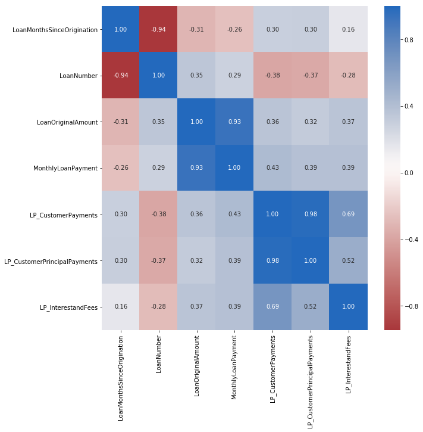

```python
plt.figure(figsize=(10,10))
indexA = data.columns.get_loc("LoanMonthsSinceOrigination")
indexB = data.columns.get_loc("LP_ServiceFees")
dataspliceB = data[data.columns[indexA:indexB]]
sb.heatmap(dataspliceB.corr(), annot = True, cmap = 'vlag_r', fmt = '.2f');
```

Another way to do this I found [here on Stack Overflow](https://stackoverflow.com/questions/17778394/list-highest-correlation-pairs-from-a-large-correlation-matrix-in-pandas)

```python
#Another way to get correlations among datasets. Will have to see how we could remove duplicates
def GetDataCorrelations(dataframe):
    corrs = dataframe.corr().abs().unstack()
    return corrs.sort_values(ascending=True)

GetDataCorrelations(data)
```

```
PublicRecordsLast12Months            ProsperPaymentsOneMonthPlusLate        5.347996e-07
ProsperPaymentsOneMonthPlusLate      PublicRecordsLast12Months              5.347996e-07
LoanFirstDefaultedCycleNumber        DebtToIncomeRatio                      5.862193e-05
DebtToIncomeRatio                    LoanFirstDefaultedCycleNumber          5.862193e-05
TotalProsperLoans                    InvestmentFromFriendsCount             9.789640e-05
InvestmentFromFriendsCount           TotalProsperLoans                      9.789640e-05
ProsperPrincipalOutstanding          PublicRecordsLast12Months              1.059005e-04
PublicRecordsLast12Months            ProsperPrincipalOutstanding            1.059005e-04
IsBorrowerHomeowner                  DebtToIncomeRatio                      1.774271e-04
DebtToIncomeRatio                    IsBorrowerHomeowner                    1.774271e-04
EmploymentStatusDuration             LP_ServiceFees                         2.007652e-04
LP_ServiceFees                       EmploymentStatusDuration               2.007652e-04
CurrentDelinquencies                 TotalTrades                            2.363269e-04
TotalTrades                          CurrentDelinquencies                   2.363269e-04
PercentFunded                        OpenRevolvingAccounts                  2.849954e-04
OpenRevolvingAccounts                PercentFunded                          2.849954e-04
TradesOpenedLast6Months              ProsperPrincipalBorrowed               3.068418e-04
ProsperPrincipalBorrowed             TradesOpenedLast6Months                3.068418e-04
ListingCategory (numeric)            TotalProsperPaymentsBilled             3.534059e-04
TotalProsperPaymentsBilled           ListingCategory (numeric)              3.534059e-04
PublicRecordsLast12Months            StatedMonthlyIncome                    4.222828e-04
StatedMonthlyIncome                  PublicRecordsLast12Months              4.222828e-04
InvestmentFromFriendsCount           RevolvingCreditBalance                 4.336717e-04
RevolvingCreditBalance               InvestmentFromFriendsCount             4.336717e-04
InvestmentFromFriendsAmount          PublicRecordsLast12Months              4.388489e-04
PublicRecordsLast12Months            InvestmentFromFriendsAmount            4.388489e-04
OpenCreditLines                      LP_CustomerPrincipalPayments           4.803322e-04
LP_CustomerPrincipalPayments         OpenCreditLines                        4.803322e-04
BankcardUtilization                  LP_CollectionFees                      6.461943e-04
LP_CollectionFees                    BankcardUtilization                    6.461943e-04
                                                                                ...
PercentFunded                        PercentFunded                          1.000000e+00
LP_NonPrincipalRecoverypayments      LP_NonPrincipalRecoverypayments        1.000000e+00
LP_NetPrincipalLoss                  LP_NetPrincipalLoss                    1.000000e+00
LP_GrossPrincipalLoss                LP_GrossPrincipalLoss                  1.000000e+00
LP_CollectionFees                    LP_CollectionFees                      1.000000e+00
LP_ServiceFees                       LP_ServiceFees                         1.000000e+00
LP_InterestandFees                   LP_InterestandFees                     1.000000e+00
LP_CustomerPrincipalPayments         LP_CustomerPrincipalPayments           1.000000e+00
LP_CustomerPayments                  LP_CustomerPayments                    1.000000e+00
MonthlyLoanPayment                   MonthlyLoanPayment                     1.000000e+00
LoanOriginalAmount                   LoanOriginalAmount                     1.000000e+00
LoanNumber                           LoanNumber                             1.000000e+00
LoanMonthsSinceOrigination           LoanMonthsSinceOrigination             1.000000e+00
LoanFirstDefaultedCycleNumber        LoanFirstDefaultedCycleNumber          1.000000e+00
LoanCurrentDaysDelinquent            LoanCurrentDaysDelinquent              1.000000e+00
ScorexChangeAtTimeOfListing          ScorexChangeAtTimeOfListing            1.000000e+00
ProsperPrincipalOutstanding          ProsperPrincipalOutstanding            1.000000e+00
ProsperPrincipalBorrowed             ProsperPrincipalBorrowed               1.000000e+00
ProsperPaymentsOneMonthPlusLate      ProsperPaymentsOneMonthPlusLate        1.000000e+00
ProsperPaymentsLessThanOneMonthLate  ProsperPaymentsLessThanOneMonthLate    1.000000e+00
OnTimeProsperPayments                OnTimeProsperPayments                  1.000000e+00
TotalProsperPaymentsBilled           TotalProsperPaymentsBilled             1.000000e+00
TotalProsperLoans                    TotalProsperLoans                      1.000000e+00
StatedMonthlyIncome                  StatedMonthlyIncome                    1.000000e+00
IncomeVerifiable                     IncomeVerifiable                       1.000000e+00
DebtToIncomeRatio                    DebtToIncomeRatio                      1.000000e+00
TradesOpenedLast6Months              TradesOpenedLast6Months                1.000000e+00
TradesNeverDelinquent (percentage)   TradesNeverDelinquent (percentage)     1.000000e+00
AvailableBankcardCredit              AvailableBankcardCredit                1.000000e+00
Investors                            Investors                              1.000000e+00
Length: 4096, dtype: float64
```

#### Univariate and Bivariate Exploration

Here I will attempt to take a quick look at some of the variables I zoomed in on in the targeted heatmaps to try an identify patterns and trends.

#### What kind of loan terms are on offer?

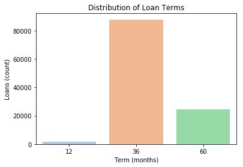

```python
#Bar plot for Term
sb.countplot(data = data, x = 'Term', palette=sb.color_palette('pastel'))
plt.xlabel('Term (months)')
plt.ylabel('Loans (count)')
plt.title('Distribution of Loan Terms')
```

#### What kind of loan status does Prosper track?

```python
data['LoanStatus'].value_counts()
```

```
Current                   56576
Completed                 38074
Chargedoff                11992
Defaulted                  5018
Past Due (1-15 days)        806
Past Due (31-60 days)       363
Past Due (61-90 days)       313
Past Due (91-120 days)      304
Past Due (16-30 days)       265
FinalPaymentInProgress      205
Past Due (>120 days)         16
Cancelled                     5
Name: LoanStatus, dtype: int64
```

**Possible Question:** What effect does having a past due loan have on whether it's completed or defaulted? We could also take a look at Past Due > 120 days for this scenario.

Prosper obviously has their own scoring system to help identify good borrowers. Assuming their system is good, what's the spread of scores?

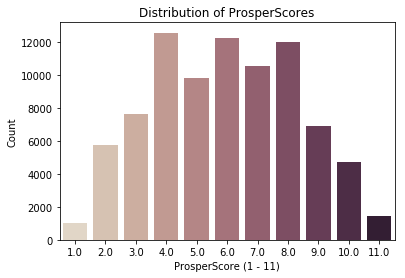

```python
#Basic barplot of prosper scores
sb.countplot(data = data, x = 'ProsperScore', palette="ch:.25")
plt.xlabel('ProsperScore (1 - 11)');
plt.ylabel('Count');
plt.title('Distribution of ProsperScores')
```

#### If I was an investor, does it matter if I invest in higher scores?

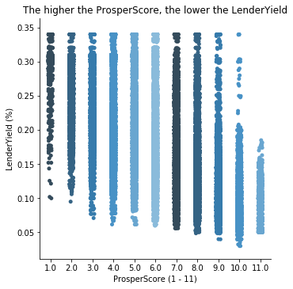

```python
#Color_palette can be either a type or a category
sb.catplot(data = data, x='ProsperScore', y = 'LenderYield', palette=sb.color_palette("Blues_d"));
plt.title('The higher the ProsperScore, the lower the LenderYield')
plt.xlabel('ProsperScore (1 - 11)');
plt.ylabel('LenderYield (%)');
```

The higher the prosper score - that is, the more capable a borrower is to repay loans - the lower the investor gets in yield. This makes sense. Another negative correlation can be seen with EstimatedLoss and ProsperRating. The higher the prosper rating, the less likely a lender experiences loss.

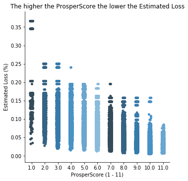

```python
sb.catplot(data = data, x='ProsperScore', y = 'EstimatedLoss', palette=sb.color_palette("Blues_d"));
plt.title('The higher the ProsperScore the lower the Estimated Loss')
plt.xlabel('ProsperScore (1 - 11)');
plt.ylabel('Estimated Loss (%)');
```

So while I earn less from good borrowers, there is less risk of loss for good borrowers (not unlike the stock market)

#### Where should I then invest? Does it matter which state I invest in terms of opportunity?

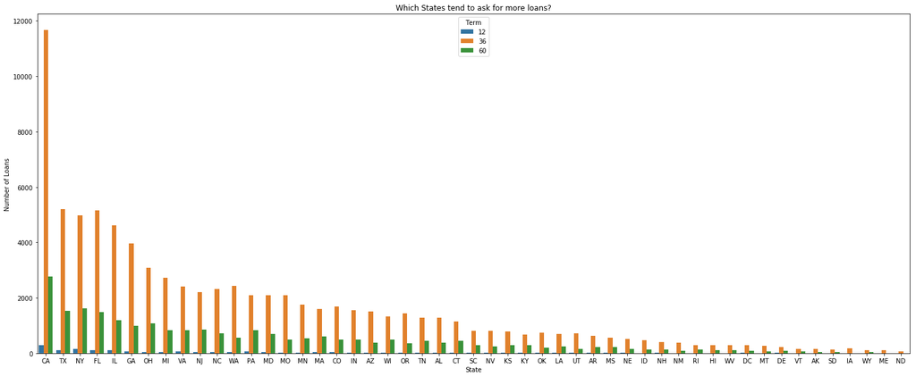

```python
#Which states tend to have the most loans?
plt.figure(figsize=(25,10))
sb.countplot(data = data, x='BorrowerState', hue = 'Term', order = data['BorrowerState'].value_counts().index);
plt.title('Which States tend to ask for more loans?')
plt.xlabel('State');
plt.ylabel('Number of Loans');
```

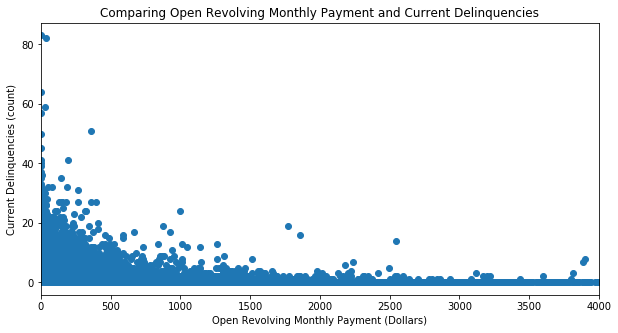

```python
#Scatter plot to analyze OpenRevolvingMonthlyPayment and CurrentDelinquencies
#Limiting xaxis values as there's not many values after 4000
plt.figure(figsize=(10,5))
plt.scatter(x="OpenRevolvingMonthlyPayment", y="CurrentDelinquencies",
            data=data);
plt.xlabel('Open Revolving Monthly Payment (Dollars)');
plt.ylabel('Current Delinquencies (count)');
plt.xlim(0, 4000)
plt.title('Comparing Open Revolving Monthly Payment and Current Delinquencies')
```

This data seems highly right skewed. I will attempt a log transformation to see if I can make more sense of this data.

```python
#Note on LogTrans: 0 values are not properly handled, thus cannot be completley trusted.
def log_trans(x, inverse=False):
    if not inverse:
        return np.log10(x)
    else:
        return np.power(10,x)

aCopy = data.copy()
aCopy.OpenRevolvingMonthlyPayment = aCopy.OpenRevolvingMonthlyPayment.apply(log_trans)
```

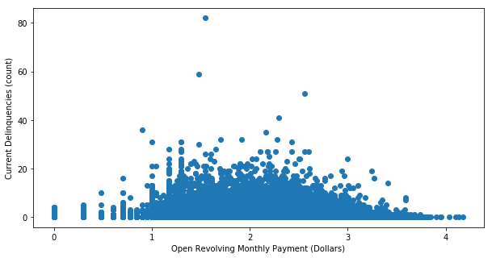

```python
plt.figure(figsize=(10,5))
plt.scatter(x="OpenRevolvingMonthlyPayment", y="CurrentDelinquencies",
            data=aCopy);
plt.xlabel('Open Revolving Monthly Payment (Dollars)');
plt.ylabel('Current Delinquencies (count)');
```

Now here's an insteresting observation. Despite a possibly acceptable thought that the more revolving monthly payment someone has, the higher risk they are of having delinquencies, this turns out to be not really the case. Log transforming the data reveals that the actual relationship is fairly normal. That is, higher revolving monthly payment doens't automatically mean they are higher risk (having more delinquencies). However, since the log transform doesn't account for about 600 0 values, we cannot take this chart at face value

To make loan status more useful, I will bucketize it.

```python
#To remove and consolidate the buckets for the "Past Due" category
loanStatusHues = [['Past Due', 'Completed', 'Defaulted', 'Current', 'Cancelled', 'Other']]
copy = data.copy()
#This is a personal decision that might or might not affect outcome, but I'm considering chargedoff as Defaulted and FInalPaymentInProgress as Completed for brevity.
def setBuckets(row):

    if('Past Due' in row):
        return 'Past Due'
    if((row in 'Completed')|(row in 'FinalPaymentInProgress')):
        return 'Completed'
    if((row in 'Defaulted') | (row in 'Chargedoff')):
        return 'Defaulted'
    if(row in 'Current'):
        return 'Current'
    if(row in 'Cancelled'):
        return 'Cancelled'
    else:
        return row

copy.LoanStatus = copy.LoanStatus.apply(lambda x: setBuckets(x))
```

```python
copy.LoanStatus.value_counts()
```

```
Current      56576
Completed    38279
Defaulted    17010
Past Due      2067
Cancelled        5
Name: LoanStatus, dtype: int64
```

#### As an investor, I expect people with poorer payment history to be worse off at paying back loans. Is this true for Prosper borrowers?

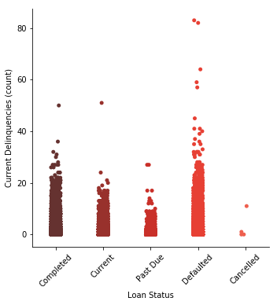

```python
# Plot to compare Delinquencies and Loan Status
sb.catplot(data = copy, x='LoanStatus', y = 'CurrentDelinquencies', palette=sb.color_palette("Reds_d"));
plt.xlabel('Loan Status');
plt.ylabel('Current Delinquencies (count)');
plt.xticks(rotation=45)
```

It looks like a fair number of people with greater delinquencies defaulted on their payments or are unable to [pay their payments for 5 or more months (Chargedoff)](https://prosper.zendesk.com/hc/en-us/articles/208500546-What-is-a-charge-off-). This can be further visualized by a cleaner line plot:

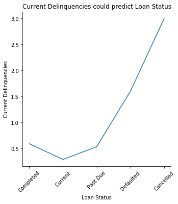

```python
#Line plot to see general trends. You could include CI to see the range of other values. Note that the y axis might change.
sb.relplot(data = copy, x='LoanStatus', y = 'CurrentDelinquencies', kind="line",  sort=False, ci=None)
plt.xticks(rotation=45)
plt.title('Current Delinquencies could predict Loan Status')
plt.xlabel('Loan Status');
plt.ylabel('Current Delinquencies');
```

```python
#Convert ListingCreationDate to datetime, only keep the date
copy['ListingCreationDate'] = pd.to_datetime(copy.ListingCreationDate).dt.date
```

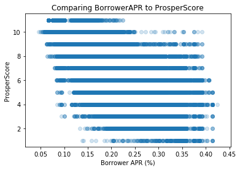

```python
#Introducing alpha to try and see a less cluttered picture
plt.scatter(data=data, x = 'BorrowerAPR', y='ProsperScore', alpha=1/5)
plt.title('Comparing BorrowerAPR to ProsperScore')
plt.xlabel('Borrower APR (%)');
plt.ylabel('ProsperScore');
```

### Exploring the Prosper Dataset from the perspective of an investor

To perform this exploration, we can pretend we're a bank and identify trends in:

- Credit History
- Cash flow
- Collateral spread
- Borrower Character

#### 1. Credit History

```python
#Previous Loans, Current Delinquencies, Credit Score, TOtal Inquiries, Debt to Income Ratio.
#Credit Score is currently a range. I will take the average of the two for each row.
BankCopy = data.copy()
```

```python
#Getting the average credit score based on the lower and upper ranges
temp = []

def GetCreditScore(row, arr):
    arr.append((row['CreditScoreRangeLower'] + row['CreditScoreRangeUpper']) / 2)

BankCopy.apply(lambda x : GetCreditScore(x,temp), axis=1)
BankCopy['CreditScoreAvg'] = temp
```

Now to validate credit history, we can look at a couple of parameters.

- Credit Score
- Current Delinquencies
- Total Inquiries
- Debit to Income Ratio
- Previous Prosper Loans (ideally this would be other loans outside of Prosper, but in this case, we'll use Prosper loan data)  
  To see how these play out with each other, we'll bucketize a couple of columns, namely:
1. Credit Score
2. Debt to Income Ratio

```python
#Bucketize Credit score (based on FICO score ranges)

def GetCreditBucket(creditscore):
    if creditscore < 580.0:
        return 'Poor'
    if creditscore >= 580.0 and creditscore <= 669.0:
        return 'Fair'
    if creditscore >= 670.0 and creditscore <= 739.0:
        return 'Good'
    if creditscore >= 740.0 and creditscore <= 799.0:
        return 'Very Good'
    return 'Excellent'

temp = BankCopy['CreditScoreAvg'].apply(lambda x: GetCreditBucket(x))
BankCopy['CreditScoreCat'] = temp
```

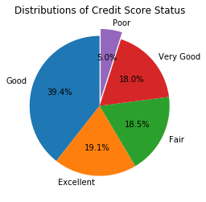

```python
plt.pie(BankCopy.CreditScoreCat.value_counts(), labels = BankCopy.CreditScoreCat.value_counts().index.tolist(), explode = [0.0, 0.0, 0.0, 0.0, 0.1], autopct='%1.1f%%',  startangle=90);
plt.title('Distributions of Credit Score Status')
```

```python
#Bucketize Debt to Income Ratio based on general internet data. Apparently 20 is an OK ratio
def GetDTIBucket(ratio):
    if ratio < 20.0:
        return 'Excellent'
    if ratio >= 20.0 and ratio <= 30.0:
        return 'Very Good'
    if ratio >= 31.0 and ratio <= 40.0:
        return 'Fair'
    if ratio >= 41.0 and ratio <= 43.0:
        return 'Poor'
    return 'Very Poor'

BankCopy['DTI_Level'] = BankCopy['DebtToIncomeRatio'].apply(lambda x: GetDTIBucket(x))
```

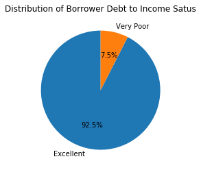

```python
#Quick look into Debt to Income distributions
plt.pie(BankCopy.DTI_Level.value_counts(), labels = BankCopy.DTI_Level.value_counts().index.tolist(), startangle=90, autopct='%1.1f%%',);
plt.title('Distribution of Borrower Debt to Income Satus')
```

```python
BankCopy.TotalInquiries.value_counts().index.max()
```

```
379.0
```

Total Inquiries has most of it's data within the first 50 units. Anything above 50 is either 2 or less than 2 (in count). The vast majority is between 0 and 10, which is a fair sign. One of the factors that affects credit score is how many inquiries you have.

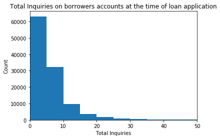

```python
#Setting xticks to manage binning. Always add +1 to max so that it's not cutoff
xticks = np.arange(0, max(BankCopy.TotalInquiries) + 1, 5)
plt.hist(BankCopy.TotalInquiries, bins = xticks)
plt.xlim(0, 50)
plt.title('Total Inquiries on borrowers accounts at the time of loan application')
plt.xlabel('Total Inquiries');
plt.ylabel('Count');
```

Now that we've bucketized two variables, we can try an identify how many people in this dataset had favourable credit history to back up their loan request.

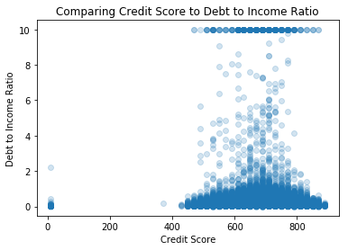

```python
#Do people with higher credit scores tend to have lower Debt-To-Income ratio?
plt.scatter(data=BankCopy, x='CreditScoreAvg', y = 'DebtToIncomeRatio', alpha = 1/5)
plt.title('Comparing Credit Score to Debt to Income Ratio')
plt.xlabel('Credit Score');
plt.ylabel('Debt to Income Ratio');
```

Doesn't necessarily look like a higher credit score means a lower DTI ratio. But does a higher DTI Ratio predict loan status? And how does credit score come into play here?

```python
BankCopy['LoanStatusCat'] = copy.LoanStatus
```

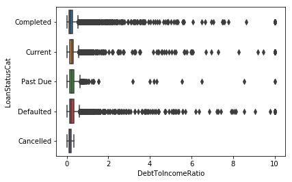

```python
sb.boxplot(data = BankCopy, x = 'DebtToIncomeRatio', y = 'LoanStatusCat')
```

Hard to see what relationships are being described here. Let's try a different plot

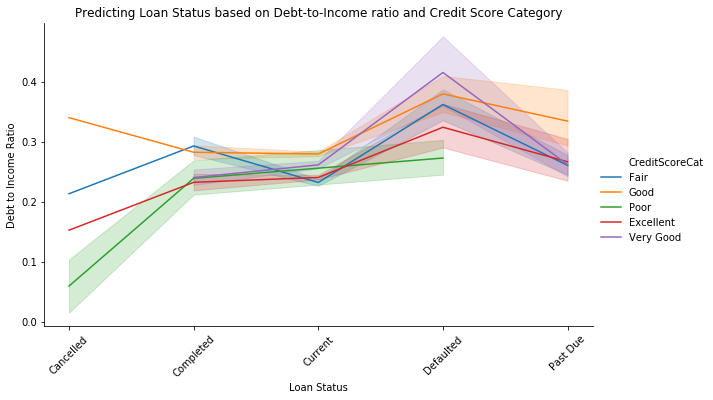

```python
#CI here looks like it's adding some noise, but I think it's fairly accurate. Graph COULD look neater without it though.
sb.relplot(data = BankCopy, x='LoanStatusCat', y = 'DebtToIncomeRatio', kind="line", hue='CreditScoreCat',sort = True, aspect=1.7)
plt.xticks(rotation=45)
plt.title('Predicting Loan Status based on Debt-to-Income ratio and Credit Score Category')
plt.xlabel('Loan Status');
plt.ylabel('Debt to Income Ratio');
```

#### Is credit score itself a good predictor of successful loans? We already know that those with good credit return less yield to investors, but also present less risk.

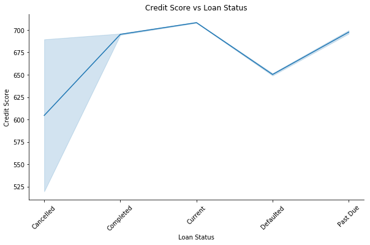

```python
#Aspect ratio for some seaborn plots for size
sb.relplot(data = BankCopy, x='LoanStatusCat', y = 'CreditScoreAvg', kind="line", sort = True, aspect=1.7)
plt.xticks(rotation=45)
plt.title('Credit Score vs Loan Status')
plt.xlabel('Loan Status');
plt.ylabel('Credit Score');
```

#### 2. Cash Flow Trends

For cash flow trends, we can look at only a few variables.

- IncomeRange
- Revolving Credit Balance
- Bankcard Utilization / Bank Card Credit

```python
BankCopy.StatedMonthlyIncome.describe()
```

```
count    1.139370e+05
mean     5.608026e+03
std      7.478497e+03
min      0.000000e+00
25%      3.200333e+03
50%      4.666667e+03
75%      6.825000e+03
max      1.750003e+06
Name: StatedMonthlyIncome, dtype: float64
```

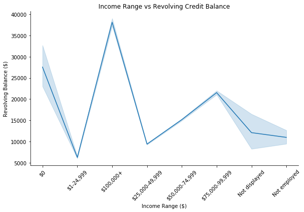

```python
#Comparing Income ranges vs Revolving Balance
sb.relplot(data = BankCopy, x='IncomeRange', y = 'RevolvingCreditBalance', kind="line", sort = True, aspect=1.7)
plt.xticks(rotation=45)
plt.title('Income Range vs Revolving Credit Balance')
plt.xlabel('Income Range ($)');
plt.ylabel('Revolving Balance ($)');
```

This relationship doesn't really say much however. It's expected that those with higher income ranges probably have a higher revolving balance. What's quirky however is those within the $0 income bracket reporting around 25,000 in balances. Though it's possible that they have probably proved that they can make the payments on time. I'd like to see what these people's credit score is.

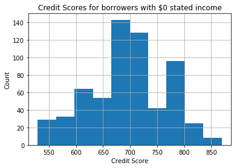

```python
#Distributions of scores for people with $0 stated income
BankCopy[(BankCopy.IncomeRange == '$0')].CreditScoreAvg.hist()
plt.title('Credit Scores for borrowers with $0 stated income')
plt.xlabel('Credit Score');
plt.ylabel('Count');
```

An average of 695? Not bad actually. Makes sense why a loan might be approved. Is their borrower rate higher though?

```python
BankCopy.BorrowerRate.describe()
```

```
count    113937.000000
mean          0.192764
std           0.074818
min           0.000000
25%           0.134000
50%           0.184000
75%           0.250000
max           0.497500
Name: BorrowerRate, dtype: float64
```

```python
#Trying to see the average borrower rate for those with 0 stated income
BankCopy[(BankCopy.IncomeRange == '$0')].BorrowerRate.describe()
```

```
count    621.000000
mean       0.195181
std        0.080353
min        0.005000
25%        0.140000
50%        0.175000
75%        0.250000
max        0.350000
Name: BorrowerRate, dtype: float64
```

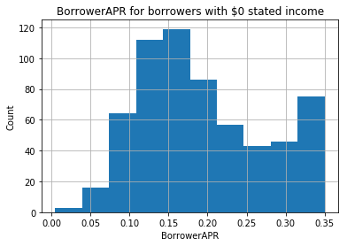

```python
#Distributions of BorrowerAPR for people with $0 stated income
BankCopy[(BankCopy.IncomeRange == '$0')].BorrowerRate.hist();
plt.title('BorrowerAPR for borrowers with $0 stated income')
plt.xlabel('BorrowerAPR');
plt.ylabel('Count');
```

A mean of 19%. It's fairly high as one might expect - credit score can only help you so much when you have no income at the time of the application.

Does bank card utilization predict loan status or credit score?

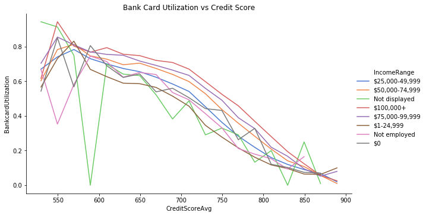

```python
#Lineplot with a hue. You could also use style to change line style instead of hue
sb.relplot(data = BankCopy, x = 'CreditScoreAvg', y = 'BankcardUtilization', hue = 'IncomeRange', palette = 'muted', kind="line", ci = None, aspect=1.7)
plt.title('Bank Card Utilization vs Credit Score')
```

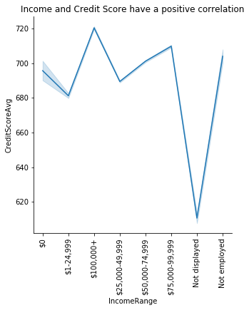

```python
#Comparing income range and Credit Score
sb.relplot(data = BankCopy, y = 'CreditScoreAvg', x = 'IncomeRange', kind="line", ci = 95)
plt.xticks(rotation = 90)
plt.title('Income and Credit Score have a positive correlation')
```

This is interesting. Bank card utilization goes down - regardless of income range - as the credit score goes up. What might explain this trend? Bank Card Utilization is basically how much of your credit (revolving) is used (at the time of getting this data). This could mean that those with higher credit scores are more scrupulous on how they spend their money. One would also expect, however, that the higher your income range, the more you are willing to spend at any given time - credit score helps too, as I also plotted the relationship between income to credit score to answer this question.

#### 3. Proof Of Collateral

Proof of collateral isn't realy something that's represented in this dataset, but there's three variables that might give us some idea:

- IsBorrowerHomeowner
- Listing Category
- Occupation

```python
BankCopy.IsBorrowerHomeowner.value_counts()
```

```
True     57478
False    56459
Name: IsBorrowerHomeowner, dtype: int64
```

```python
BankCopy.head(1)
```

|  | ListingKey | ListingNumber | ListingCreationDate | CreditGrade | Term | LoanStatus | ClosedDate | BorrowerAPR | BorrowerRate | LenderYield | EstimatedEffectiveYield | EstimatedLoss | EstimatedReturn | ProsperRating (numeric) | ProsperRating (Alpha) | ProsperScore | ListingCategory (numeric) | BorrowerState | Occupation | EmploymentStatus | EmploymentStatusDuration | IsBorrowerHomeowner | CurrentlyInGroup | GroupKey | DateCreditPulled | CreditScoreRangeLower | CreditScoreRangeUpper | FirstRecordedCreditLine | CurrentCreditLines | … |
| --- | --- | --- | --- | --- | --- | --- | --- | --- | --- | --- | --- | --- | --- | --- | --- | --- | --- | --- | --- | --- | --- | --- | --- | --- | --- | --- | --- | --- | --- | --- |
| 0 | 1021339766868145413AB3B | 193129 | 2007-08-26 19:09:29.263000000 | C | 36 | Completed | 2009-08-14 00:00:00 | 0.16516 | 0.158 | 0.138 | NaN | NaN | NaN | NaN | NaN | NaN | 0 | CO | Other | Self-employed | 2.0 | True | True | NaN | 2007-08-26 18:41:46.780000000 | 640.0 | 659.0 | 2001-10-11 00:00:00 | 5.0 | … |

This dataset's listing category is numeric, and maps to these values:

0 - Not Available, 1 - Debt Consolidation, 2 - Home Improvement, 3 - Business, 4 - Personal Loan, 5 - Student Use, 6 - Auto, 7- Other, 8 - Baby&Adoption, 9 - Boat, 10 - Cosmetic Procedure, 11 - Engagement Ring, 12 - Green Loans, 13 - Household Expenses, 14 - Large Purchases, 15 - Medical/Dental, 16 - Motorcycle, 17 - RV, 18 - Taxes, 19 - Vacation, 20 - Wedding Loans

To check collateral, we can discard some of these categories, as we don't expect them to be considered collateral. Thus we're left with:

- Home Improvement
- Business
- Auto
- Boat
- Household Expenses
- RV
- Motorcycle
- Engagement Ring
- Large Purchases

While there are some categories could be considered collateral, I'm not inlcuding them for now as I'm only considering physical property as valid collateral. Now, I'll create another column for these categorical variables. Those that are not in the final list will be labled as 'other'. Before that, I'll quickly rename the column.

```python
BankCopy.rename(columns={'ListingCategory (numeric)':'ListingCategory'}, inplace=True)
```

```python
#Getting collateral type, binning with switch statement.
#Any collateral that isn't traditionally considered collateral OR any loans without collateral are binned into "other"

newcol = []

def GetCollateralCategory(row, col):
    switch = {
        2: "Home Improvement",
        3: "Business",
        6: "Auto",
        9: "Boat",
        11: "Engagement Ring",
        13: "Household Expenses",
        14: "Large Purchases",
        16: "Motorcycle",
        17: "RV"
    }
    return switch.get(row, "Other")

BankCopy.ListingCategory = BankCopy.ListingCategory.apply(lambda x: GetCollateralCategory(x, newcol))
```

```python
BankCopy.ListingCategory.value_counts()
```

```
Other                 93213
Home Improvement       7433
Business               7189
Auto                   2572
Household Expenses     1996
Large Purchases         876
Motorcycle              304
Engagement Ring         217
Boat                     85
RV                       52
Name: ListingCategory, dtype: int64
```

Now, I'll try and see if there's anything I can glean from these variables.

#### As an investor, I'd like to know if I should focus on these borrowers that have acceptable collateral in terms of yield.

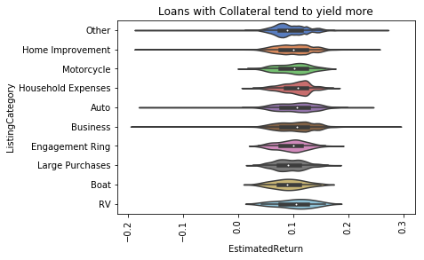

```python
#The problem with violin plots is if there are too many variables, it's harder to compare. Example below.
sb.violinplot(data = BankCopy, y = 'ListingCategory', x = 'EstimatedReturn', palette= 'muted');
plt.xticks(rotation = 90);
plt.title('Loans with Collateral tend to yield more');
```

From the looks of it, borrowers with valid collateral - save for boats - seem to have slightly higher returns. We could use another chart to see this more clearly with the LenderYield variable. RV's and household improvements and expenses seem to have some solid returns!

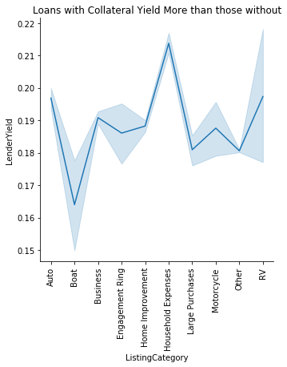

```python
#Plotting Listing Category vs Lender Yield
sb.relplot(data = BankCopy, x = 'ListingCategory', y = 'LenderYield', kind = 'line')
plt.xticks(rotation = 90);
plt.title('Loans with Collateral Yield More than those without');
```

Since home owners seem to have excellent yields, we can take a quick look at this category.

```python
#Set the y values to the category for easy label viewing. Better than rotating the xticks.
sb.countplot(data = BankCopy[BankCopy.ListingCategory != 'Other'], y = 'ListingCategory', hue = 'IsBorrowerHomeowner');
plt.xticks(rotation = 45);
plt.title('Count of Homeowners in relation to Collateral');
```

[output not shown]

#### 4.Character

This is an interesting parameter, as there aren't usually numeric data for such a query. However, we could scrape together a few things from this dataset to aid us in understanding the character of the borrowers Prosper houses.

- Credit Score
- Total Prosper Loans
- Recommendations
- Investors
- Investment from Friends

We've already discussed credit score in the first category, so I'm going to skip it for individual analysis. Why the rest of the variables? I chose them because they:

1. Show that they have history with Prosper (relationship with the bank)
2. Show that they are deemed worthy of investment by others (Investors/InvestmentFromFriends)
3. Show that previous loans have been successful, or people know that they can be trusted (recommendations)

In addition, I might look at a few more variables to gauge individuals' trustworthiness.

- PercentFunded
- LoanOriginalAmount
- InvestmentFromFriendsAmount

First, a couple of basic bi and univariate plots

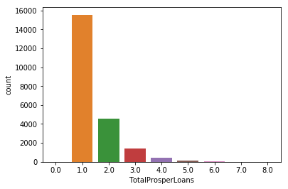

```python
sb.countplot(data = BankCopy, x = 'TotalProsperLoans')
```

Looks like a majority of people are here for one loan (their first loan)

```
(0, 4)
```

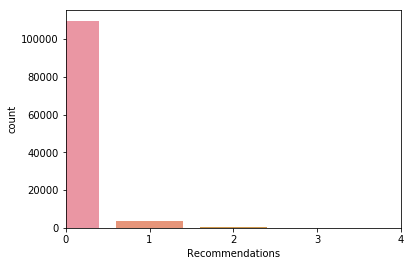

```python
sb.countplot(data = BankCopy, x = 'Recommendations')
plt.xlim(0,4)
```

```python
BankCopy.PercentFunded.value_counts().head(10)
```

```
1.0000    113067
0.9998         5
0.7000         4
0.8087         4
0.7784         3
0.7189         3
0.9086         3
0.7395         3
0.7142         3
0.7803         3
Name: PercentFunded, dtype: int64
```

```
(0, 5)
```

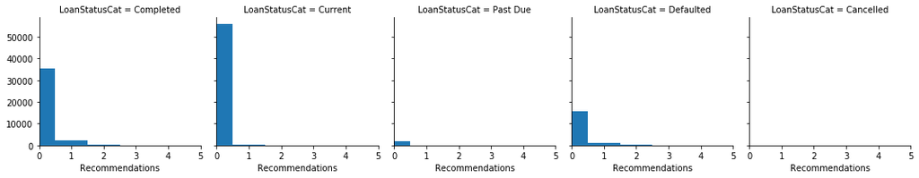

```python
#In the exmaple here and the ones following, FacetGrid is really something I need to figure out good datapoints for.
bins = np.arange(0, max(BankCopy.Recommendations)+1, 1)
g = sb.FacetGrid(data = BankCopy, col = 'LoanStatusCat')
g.map(plt.hist, 'Recommendations', bins = bins, align='left')
plt.xlim(0, 5)
```

Recommendations are few and far between. There isn't much we can get out of it.

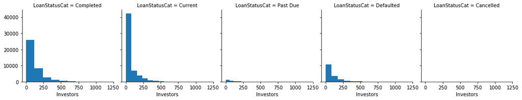

```python
g = sb.FacetGrid(data = BankCopy, col = 'LoanStatusCat')
g.map(plt.hist, 'Investors')
```

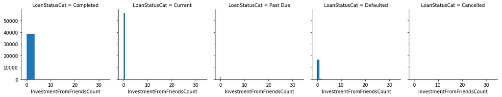

```python
g = sb.FacetGrid(data = BankCopy, col = 'LoanStatusCat')
g.map(plt.hist, 'InvestmentFromFriendsCount')
```

There isn't much we can get from these variables it seems. However, one thing we could try and do is create a "character score" for each loan which takes a look at these numerical values, and sets a numeric score. Prosper already has their own scoring system, but doesn't look at character level traits I've identified. Their scoring system uses:

- Number of inquiries on the credit bureau
- Number of delinquent accounts on the credit bureau
- Credit card utilization on the credit bureau
- Number of recently opened trades on the credit bureau
- Debt to income ratio
- Loan payment performance on prior Prosper loans

What I'll do is include the above variables into consideration and see how that matches with prosper score. I'll add a basic scoring system that starts off at 0, and either goes up or down based on the variable in question.

Can we include more variables? Sure. Do we need to? No. At this point we're just trying to get a hang of the data, so there's no need to delve too deep into the system. I'm a demanding investor, however, and so my conditions for a good character score are fairly high.

```python
#Creating our own variable here based on a multitute of other ones. Sending in row, using columns with that.
score_col = []

def get_character_score(row):
    score = 0
    if(row.InquiriesLast6Months is not None):
        if(row.InquiriesLast6Months > 4):
            score += row.InquiriesLast6Months * -1

    if(row.TotalInquiries is not None):
        if(row.TotalInquiries > 7):
            score += row.TotalInquiries * -1

    if(row.CurrentDelinquencies is not None):
        if(row.CurrentDelinquencies > 1):
            score += row.CurrentDelinquencies * -1

    if(row.DTI_Level is not None):
        if(('Excellent' in row.DTI_Level) | ('Very Good' in row.DTI_Level)):
            score += 2
        elif(('Poor' in row.DTI_Level) | ('Very Poor' in row.DTI_Level)):
            score -= 1

    if(row.Investors is not None):
        if(row.Investors > 1):
            score += 2
        else:
            score += row.Investors

    if(row.InvestmentFromFriendsCount is not None):
        score += row.InvestmentFromFriendsCount

    if(row.Recommendations is not None):
        score += row.Recommendations

    if(row.ProsperPaymentsOneMonthPlusLate is not None):
        if(row.ProsperPaymentsOneMonthPlusLate > 2):
            score += row.ProsperPaymentsOneMonthPlusLate * -1
        if(row.ProsperPaymentsOneMonthPlusLate == 0):
            score += 2

    score_col.append(score)

BankCopy.apply(lambda x: get_character_score(x), axis = 1)
BankCopy['CharacterScore'] = score_col
```

```
(-50, 50)
```

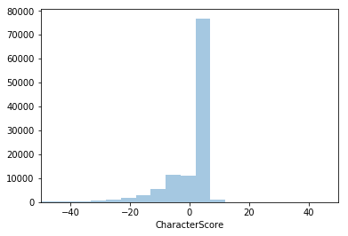

```python
bins = np.arange(min(BankCopy.CharacterScore), max(BankCopy.CharacterScore), 5)
sb.distplot(BankCopy.CharacterScore, bins=bins, kde=False)
plt.xlim(-50, 50)
```

Let's see how this lines up with ProsperScore. Do they follow a similar pattern?

```
(-10, 250)
```

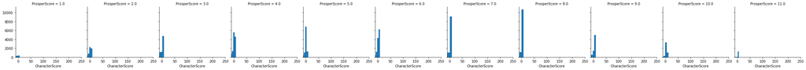

```python
#Another example of a mostly useless FacetGrid
g = sb.FacetGrid(BankCopy, col = 'ProsperScore')
g.map(plt.hist, 'CharacterScore')
plt.xlim(-10, 250)
```

From the looks of it, the higher the ProsperScore, the higher the CharacterScore. To confirm, we can use a linegraph:

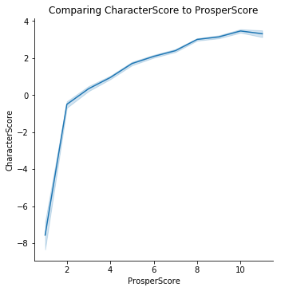

```python
sb.relplot(data=BankCopy, x = 'ProsperScore', y = 'CharacterScore', kind = 'line', sort = True)
plt.title("Comparing CharacterScore to ProsperScore")
```

```python
BankCopy[BankCopy.ProsperScore > 6]
```

[output not shown]

35767 rows × 86 columns

```
(-150, 73.0)
```

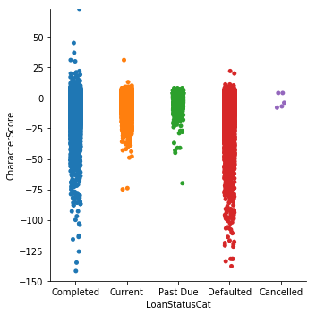

```python
#Cat plots are pretty nice in this scenario. Easy to see spread, and can cutoff values to see more detail (next graph)
sb.catplot(data = BankCopy, x = 'LoanStatusCat', y = 'CharacterScore')
plt.ylim(-150,BankCopy.CharacterScore.max())
```

Interestingly, character score isn't a full proof method of evaluating loan outcomes. In particular, InquiriesLast6Months, TotalInquiries and current delinquencies really seem to drag ratings down. Both completed and defaulted have almost the same ranges of scores. The point that makes it harder to compare with prosper score is that ProsperScore's are never negative. If I were to limit the minimum to 0:

```
(0, 73.0)
```

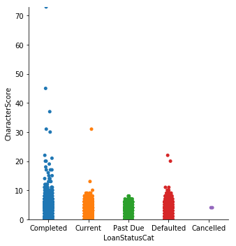

```python
sb.catplot(data = BankCopy, x = 'LoanStatusCat', y = 'CharacterScore')
plt.ylim(0,BankCopy.CharacterScore.max())
```

This makes a teeny bit more sense. One thing to note is that I've lumbed ChargedOff and Defaulted into one category, so those numbers aren't all representative of Defaulted.

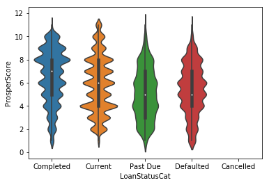

```python
sb.violinplot(data = BankCopy, x = 'LoanStatusCat', y = 'ProsperScore')
```

```python
BankCopy.to_csv('FinalDataset.csv', index=False)
```